# Assignment5

Megan Willis-Jackson

10/8/2020

# Load Libraries

```r
library(tidyverse)
library(jtools)
library(interactions)
library(knitr)
library(ggthemes)
```

# Clean Data

```r
people<- read.csv("people.csv")
people<- people[,2:7]

education<- unique(people$highest_education)

people_mutated<- people %>%
  mutate(education_binary = case_when(
    highest_education == "Master's degree" ~ "Post HS",
    highest_education == "Associate's degree" ~ "Post HS",
    highest_education == "Regular high school deploma" ~ "HS/equivalent or less",
    highest_education == "Bachelor's degree" ~ "Post HS",
    highest_education == "1 or more years of college credit, no degree" ~ "Post HS",
    highest_education == "Grade 11" ~ "HS/equivalent or less",
    highest_education == "GED or alternative credential" ~ "HS/equivalent or less",
    highest_education == "Some college, but less than 1 year" ~ "HS/equivalent or less",
    highest_education == "Professional degree beyond a bachelor's degree" ~ "Post HS",
    highest_education == "No schooling completed" ~ "HS/equivalent or less",
    highest_education == "Grade 10" ~ "HS/equivalent or less",
    highest_education == "Doctorate degree" ~ "Post HS",
    highest_education == "Grade 7" ~ "HS/equivalent or less",
    highest_education == "12th grade - no diploma" ~ "HS/equivalent or less",
    highest_education == "Grade 9" ~ "HS/equivalent or less",
    highest_education == "Grade 8" ~ "HS/equivalent or less",
    highest_education == "Grade 6" ~ "HS/equivalent or less",
    highest_education == "Grade 3" ~ "HS/equivalent or less",
    highest_education == "Grade 4" ~ "HS/equivalent or less",
    highest_education == "Grade 5" ~ "HS/equivalent or less",
    highest_education == "Grade 2" ~ "HS/equivalent or less",
    highest_education == "Grade 1" ~ "HS/equivalent or less",
    highest_education == "Kindergarten" ~ "HS/equivalent or less",
    highest_education == "Nursery school, preschool" ~ "HS/equivalent or less",
    highest_education == "Regular high school diploma" ~ "HS/equivalent or less"
  ))

people_mutated$transpo_mode<- str_replace_all(people_mutated$transpo_mode, "Car, truck, or van", "1Car, truck, or van")
```

# Run Regression for Each Model

## Model 1

To start off, I will note that for Assignment 4, I had designated my dependent variable as the amount of time it takes a MA resident to commute to work. I had an r-squared value of ~0.12, so my variables did not predict the variance in travel time very well. As I thought more about the variables I collected, I realized that in fact it may make more sense to have housing costs as the dependent variable. Housing costs are often correlated with location from wherever the concentration of jobs may be (i.e., lower travel time). Oftentimes people may even choose where to live based on how it will affect their commute length. Therefore, I ran with housing costs as my dependent variable, and compare all new models to the model 1 below.

```r
options(scipen = 999)
model1 <- lm(monthly_housing_total ~ transpo_mode + education_binary + household_income + travel_time,
            data = people_mutated)

summary(model1)
```

```
##
## Call:
## lm(formula = monthly_housing_total ~ transpo_mode + education_binary +
##     household_income + travel_time, data = people_mutated)
##
## Residuals:
##     Min      1Q  Median      3Q     Max
## -5955.6  -527.6   -90.0   412.5  6285.9
##
## Coefficients:
##                                                                         Estimate
## (Intercept)                                                         964.20660734
## transpo_modeBicycle                                                 307.52666048
## transpo_modeBus or trolley bus                                       82.86710734
## transpo_modeFerryboat                                               344.31988483
## transpo_modeMotorcycle                                              298.07786847
## transpo_modeOther method                                             94.84796360
## transpo_modeRailroad                                                185.58109283
## transpo_modeStreetcar or trolley car (carro publico in Puerto Rico) 330.95322966
## transpo_modeSubway or elevated                                      286.41065970
## transpo_modeTaxicab                                                 252.58716403
## transpo_modeWalked                                                  273.99748919
## education_binaryPost HS                                             275.98974523
## household_income                                                      0.00375745
## travel_time                                                           1.47637227
##                                                                       Std. Error
## (Intercept)                                                          13.02677182
## transpo_modeBicycle                                                  54.41657028
## transpo_modeBus or trolley bus                                       31.56088759
## transpo_modeFerryboat                                               144.49867969
## transpo_modeMotorcycle                                              284.79963771
## transpo_modeOther method                                             61.45984731
## transpo_modeRailroad                                                 39.49406249
## transpo_modeStreetcar or trolley car (carro publico in Puerto Rico) 117.45510801
## transpo_modeSubway or elevated                                       23.78734236
## transpo_modeTaxicab                                                  95.66217661
## transpo_modeWalked                                                   26.37781532
## education_binaryPost HS                                              12.34929119
## household_income                                                      0.00004624
## travel_time                                                           0.24650810
```

[output cut: 36 more lines]

```
## transpo_modeOther method
## transpo_modeRailroad                                                ***
## transpo_modeStreetcar or trolley car (carro publico in Puerto Rico) **
## transpo_modeSubway or elevated                                      ***
## transpo_modeTaxicab                                                 **
## transpo_modeWalked                                                  ***
## education_binaryPost HS                                             ***
## household_income                                                    ***
## travel_time                                                         ***
## ---
## Signif. codes:  0 '***' 0.001 '**' 0.01 '*' 0.05 '.' 0.1 ' ' 1
##
## Residual standard error: 900.4 on 27213 degrees of freedom
## Multiple R-squared:  0.2491, Adjusted R-squared:  0.2487
## F-statistic: 694.2 on 13 and 27213 DF,  p-value: < 0.00000000000000022
```

## Model 2

Ultimately, however, this model decreases the R-squared value from model 1, meaning the independent variables explain less of the variation in monthly housing costs for MA residents.

```r
model2 <- lm(monthly_housing_total ~ transpo_mode + education_binary + log(household_income) + travel_time,
            data = people_mutated)

summary(model2)
```

```
##
## Call:
## lm(formula = monthly_housing_total ~ transpo_mode + education_binary +
##     log(household_income) + travel_time, data = people_mutated)
##
## Residuals:
##     Min      1Q  Median      3Q     Max
## -3362.4  -538.0  -102.3   397.9  7115.8
##
## Coefficients:
##                                                                       Estimate
## (Intercept)                                                         -4997.5168
## transpo_modeBicycle                                                   320.9646
## transpo_modeBus or trolley bus                                        145.6069
## transpo_modeFerryboat                                                 439.3887
## transpo_modeMotorcycle                                                196.5921
## transpo_modeOther method                                              212.4236
## transpo_modeRailroad                                                  214.0009
## transpo_modeStreetcar or trolley car (carro publico in Puerto Rico)   336.8224
## transpo_modeSubway or elevated                                        293.6626
## transpo_modeTaxicab                                                   335.2889
## transpo_modeWalked                                                    368.7613
## education_binaryPost HS                                               256.7632
## log(household_income)                                                 561.2245
## travel_time                                                             1.3199
##                                                                     Std. Error
## (Intercept)                                                            83.9408
## transpo_modeBicycle                                                    55.0562
## transpo_modeBus or trolley bus                                         31.9887
## transpo_modeFerryboat                                                 146.1751
## transpo_modeMotorcycle                                                288.1587
## transpo_modeOther method                                               62.1934
## transpo_modeRailroad                                                   39.9473
## transpo_modeStreetcar or trolley car (carro publico in Puerto Rico)   118.8410
## transpo_modeSubway or elevated                                         24.0701
## transpo_modeTaxicab                                                    96.8128
## transpo_modeWalked                                                     26.7645
## education_binaryPost HS                                                12.5839
## log(household_income)                                                   7.3567
## travel_time                                                             0.2496
```

[output cut: 36 more lines]

```
## transpo_modeOther method                                            ***
## transpo_modeRailroad                                                ***
## transpo_modeStreetcar or trolley car (carro publico in Puerto Rico) **
## transpo_modeSubway or elevated                                      ***
## transpo_modeTaxicab                                                 ***
## transpo_modeWalked                                                  ***
## education_binaryPost HS                                             ***
## log(household_income)                                               ***
## travel_time                                                         ***
## ---
## Signif. codes:  0 '***' 0.001 '**' 0.01 '*' 0.05 '.' 0.1 ' ' 1
##
## Residual standard error: 911 on 27213 degrees of freedom
## Multiple R-squared:  0.2313, Adjusted R-squared:  0.2309
## F-statistic: 629.8 on 13 and 27213 DF,  p-value: < 0.00000000000000022
```

## Model 3

For model3, I have sorted the modes of transportation into four categories as opposed to the 11 that MA residents used. This yields an R-squared value of 0.248, which still isn’t quite as high as model1 with no transformations. It does, however, make the results a lot easier to quickly interpret. We find that people who walk or bike to work on average pay about $280 more in monthly housing costs than people who drive to work, and people who take public transit pay about $210 more per month, all statistically significant at the 95% confidence level.

```r
people_mutated <- people_mutated %>%
  mutate(transpo_categories = case_when(
    transpo_mode == "1Car, truck, or van" ~ "1drive",
    transpo_mode == "Subway or elevated" ~ "public transit",
    transpo_mode == "Walked" ~ "walk/bike",
    transpo_mode == "Railroad" ~ "public transit",
    transpo_mode == "Bus or trolley bus" ~ "public transit",
    transpo_mode == "Streetcar or trolley car (carro publico in Puerto Rico)" ~ "public transit",
    transpo_mode == "Bicycle" ~ "walk/bike",
    transpo_mode == "Other method" ~ "other",
    transpo_mode == "Taxicab" ~ "1drive",
    transpo_mode == "Ferryboat" ~ "public transit",
    transpo_mode == "Motorcycle" ~ "1drive"))

model3 <- lm(monthly_housing_total ~ transpo_categories + education_binary + household_income + travel_time,
            data = people_mutated)

summary(model3)
```

```
##
## Call:
## lm(formula = monthly_housing_total ~ transpo_categories + education_binary +
##     household_income + travel_time, data = people_mutated)
##
## Residuals:
##     Min      1Q  Median      3Q     Max
## -5887.6  -529.1   -89.7   414.1  6281.8
##
## Coefficients:
##                                      Estimate   Std. Error t value
## (Intercept)                      963.59477035  12.89961875  74.699
## transpo_categoriesother           94.30558051  61.49444825   1.534
## transpo_categoriespublic transit 212.38390231  17.91762966  11.853
## transpo_categorieswalk/bike      278.38087054  24.01515065  11.592
## education_binaryPost HS          279.11331865  12.33682110  22.624
## household_income                   0.00376167   0.00004612  81.561
## travel_time                        1.44238979   0.24417896   5.907
##                                              Pr(>|t|)
## (Intercept)                      < 0.0000000000000002 ***
## transpo_categoriesother                         0.125
## transpo_categoriespublic transit < 0.0000000000000002 ***
## transpo_categorieswalk/bike      < 0.0000000000000002 ***
## education_binaryPost HS          < 0.0000000000000002 ***
## household_income                 < 0.0000000000000002 ***
## travel_time                             0.00000000352 ***
## ---
## Signif. codes:  0 '***' 0.001 '**' 0.01 '*' 0.05 '.' 0.1 ' ' 1
##
## Residual standard error: 900.9 on 27220 degrees of freedom
## Multiple R-squared:  0.248,  Adjusted R-squared:  0.2478
## F-statistic:  1496 on 6 and 27220 DF,  p-value: < 0.00000000000000022
```

## Model 4

I would think that there is an interaction between people’s modes of transportation and the speed with which they get to work; I will therefore next try test an interaction between the mode of transportation and travel time.

This model also has an R-squared value of 0.249, almost equal to model1 in that they both explain almost 25% of the variances in monthly housing costs for MA residents. However, as this model provides additional useful information about the relationship between housing costs and the other variables, I will select this model.

```r
model4 <- lm(monthly_housing_total ~ transpo_categories + education_binary + household_income + travel_time + transpo_categories:travel_time,
            data = people_mutated)

summary(model4)
```

```
##
## Call:
## lm(formula = monthly_housing_total ~ transpo_categories + education_binary +
##     household_income + travel_time + transpo_categories:travel_time,
##     data = people_mutated)
##
## Residuals:
##     Min      1Q  Median      3Q     Max
## -5901.4  -525.8   -90.1   412.0  6281.3
##
## Coefficients:
##                                                  Estimate   Std. Error t value
## (Intercept)                                  940.69819045  13.32897896  70.575
## transpo_categoriesother                      249.51034917  82.34040670   3.030
## transpo_categoriespublic transit             390.94399081  36.29843299  10.770
## transpo_categorieswalk/bike                  368.58959790  37.27263700   9.889
## education_binaryPost HS                      276.80892452  12.33261024  22.445
## household_income                               0.00376374   0.00004611  81.633
## travel_time                                    2.25725015   0.27232764   8.289
## transpo_categoriesother:travel_time           -4.46446500   1.53165145  -2.915
## transpo_categoriespublic transit:travel_time  -3.96963477   0.68726488  -5.776
## transpo_categorieswalk/bike:travel_time       -4.52630546   1.57405636  -2.876
##                                                          Pr(>|t|)
## (Intercept)                                  < 0.0000000000000002 ***
## transpo_categoriesother                                   0.00245 **
## transpo_categoriespublic transit             < 0.0000000000000002 ***
## transpo_categorieswalk/bike                  < 0.0000000000000002 ***
## education_binaryPost HS                      < 0.0000000000000002 ***
## household_income                             < 0.0000000000000002 ***
## travel_time                                  < 0.0000000000000002 ***
## transpo_categoriesother:travel_time                       0.00356 **
## transpo_categoriespublic transit:travel_time        0.00000000773 ***
## transpo_categorieswalk/bike:travel_time                   0.00404 **
## ---
## Signif. codes:  0 '***' 0.001 '**' 0.01 '*' 0.05 '.' 0.1 ' ' 1
##
## Residual standard error: 900.2 on 27217 degrees of freedom
## Multiple R-squared:  0.2492, Adjusted R-squared:  0.249
## F-statistic:  1004 on 9 and 27217 DF,  p-value: < 0.00000000000000022
```

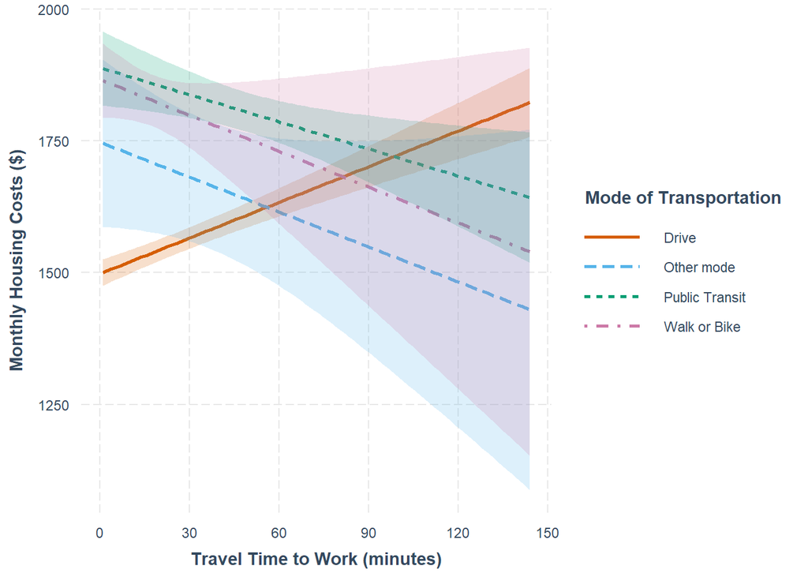

```r
interact_plot(model4,
              pred = travel_time,
              modx = transpo_categories,
              interval = T,
              modx.labels = c("Drive", "Other mode", "Public Transit", "Walk or Bike"),
              legend.main = "Mode of Transportation", colors = "CUD") +
  scale_x_continuous(name = "Travel Time to Work (minutes)",
                     breaks = seq(0, 150, by = 30)) +
  scale_y_continuous(name = "Monthly Housing Costs ($)") +
  theme()
```

# Models Side-by-Side

The chart below makes it quite clear which of the models predict the dependent variable with the most accuracy. Three of the models are very similar (1, 3, and 4), while model 2 predicts almost two percent less of the variance in housing costs in our dataset.

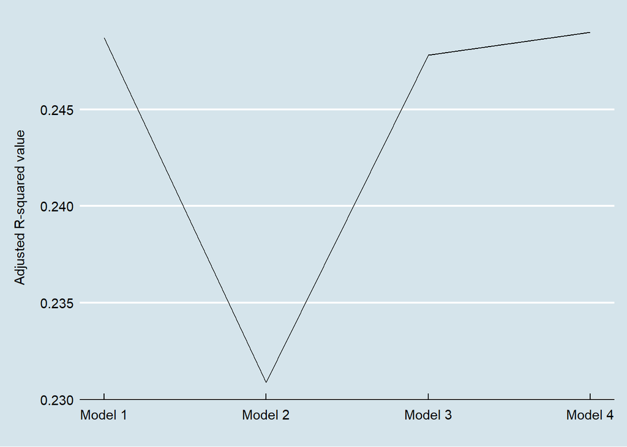

```r
ModelFit <- tibble(model = c(1, 2, 3, 4),
                   R_square = c(summary(model1)$adj.r.squared,
                                summary(model2)$adj.r.squared,
                                summary(model3)$adj.r.squared,
                                summary(model4)$adj.r.squared))

ggplot(ModelFit, aes(x = model, y = R_square)) +
  geom_line() +
  scale_x_continuous(name = "",
                   breaks = breaks <- seq(1, 4, by = 1),
                   labels = paste("Model", breaks)) +
  scale_y_continuous(name = "Adjusted R-squared value\n") +
  theme_economist()
```